# 京津冀

# 京津冀

熵权法、灰色关联分析法以及主成分分析法得出的权重如下

```
##          熵权法     主成分   灰色关联
## 人口 0.05045729 0.08172139 0.08172139
## GD   0.05292580 0.06778303 0.06778303
## 二产 0.06136654 0.04411845 0.04411845
## 三产 0.05247540 0.07865188 0.07865188
## 高学 0.09501299 0.08644659 0.08644659
## 城市 0.06481190 0.08455651 0.08455651
## pH   0.03712173 0.05075499 0.05075499
## DO   0.02385443 0.02512185 0.02512185
## CO   0.05061465 0.07227528 0.07227528
## NH   0.14238945 0.04936505 0.04936505
## 13类 0.05431622 0.07756261 0.07756261
## 污水 0.03410218 0.02642202 0.02642202
## 降水 0.06445360 0.00135672 0.00135672
## 建成 0.03711659 0.07120271 0.07120271
## 森林 0.07948742 0.08549193 0.08549193
## 人均 0.05717704 0.06150738 0.06150738
## 利用 0.04231677 0.03566161 0.03566161
```

一致性检验结果如下：

```
##  Kendall's coefficient of concordance W
##
##  Subjects = 36
##    Raters = 3
##         W = 0.99
##
## Chisq(35) = 104
##   p-value = 9.12e-09
```

评价结果如下：

```
##         日期     北京     天津     河北   京津冀
## 1 2014-05-02 2.025690 2.631890 2.989147 2.376659
## 2 2013-05-02 1.992781 2.643248 2.610512 2.287371
## 3 2012-05-02 1.752267 2.604640 2.957323 2.323191
## 4 2011-05-02 1.699660 2.689944 2.991444 2.524859
## 5 2010-05-02 1.773890 2.836852 2.995310 2.571311
## 6 2009-05-02 1.880805 2.737284 3.194438 2.687474
## 7 2008-05-02 1.915499 2.829801 3.411062 2.790100
## 8 2007-05-02 2.183664 3.160895 3.538017 3.003146
## 9 2006-05-02 2.172406 3.118205 3.476394 3.074163
```

## 北京

北京市2006-2014年各指标数据如下表所示

```
##      人口    GD  二产  三产      高学      城市       pH       DO       CO
## 2014 4.83  7.30 21.31 77.95 0.3615679 0.8633829 8.086058 8.867019 1.896154
## 2013 4.41  7.70 22.30 76.90 0.3929758 0.8628842 8.052019 9.173846 2.527885
## 2012 4.74  7.73 22.70 76.46 0.3557859 0.8622523 7.949286 9.373929 2.411607
## 2011 4.02  8.10 23.10 76.10 0.3245390 0.8618128 8.167115 8.930962 2.805769
## 2010 3.07 10.30 24.00 75.10 0.3090965 0.8593272 8.078515 8.970000 2.378218
## 2009 3.50 10.19 23.50 75.50 0.2936539 0.8500000 8.026289 8.671546 2.135052
## 2008 3.42  9.10 25.70 73.20 0.2690880 0.8492377 8.173523 9.226932 2.552273
## 2007 3.40 14.50 26.80 72.10 0.2894737 0.8448687 7.897624 8.189802 2.485000
## 2006 1.29 12.80 27.80 70.90 0.2827760 0.8432230 8.249146 7.943659 4.646341
##             NH 13类 污水 降水   建成 森林   人均      利用
## 2014 0.1677885 46.9 86.1  439 49.130 35.8  95.15 1.8467980
## 2013 0.1423077 49.8 84.6  501 47.100 35.8 118.59 1.4663442
## 2012 0.2083036 53.6 83.0  708 46.200 35.8 193.24 0.9083544
## 2011 0.2573077 55.1 82.0  522 45.600 35.8 134.71 1.3129429
## 2010 0.1920792 55.5 81.0  524 46.645 35.8 124.20 1.5251300
## 2009 0.2642708 55.8 80.3  448 47.690 35.8 126.61 1.6254579
## 2008 0.2469767 55.9 78.9  638 37.150 21.3 205.53 1.0257310
## 2007 0.1881188 50.7 76.3  499 36.170 21.3 148.16 1.4619908
## 2006 0.3125610 48.5 73.2  448 44.350 21.3 141.52 1.5541459
```

评价标准如下：

```
##   人口   GD 二产 三产 高学 城市  pH  DO CO   NH 13类 污水 降水 建成 森林
## 1  6.3 8.25 25.0 65.0 0.20 0.84 6~9 7.5  2 0.15   80   80 1500   80   80
## 2  5.0 7.75 43.0 60.0 0.15 0.79 6~9 6.0  4 0.50   70   70 1000   60   60
## 3  4.1 7.25 52.0 51.4 0.12 0.69 6~9 5.0  6 1.00   60   60  700   50   50
## 4  3.5 7.00 52.7 46.0 0.10 0.50 6~9 3.0 10 1.50   50   40  500   40   40
## 5  2.5 6.75 55.0 35.4 0.06 0.47 6~9 2.0 15 2.00   40   20  100   20   20
##   人均 利用
## 1 2300  0.1
## 2 1700  0.3
## 3 1100  0.8
## 4  700  1.5
## 5  500  1.7
```

各指标所属的等级以及概率

```
##      2014 2013 2012 2011 2010 2009 2008 2007 2006
## 人口    2    3    2    3    4    4    4    4    5
## GD      3    2    2    1    1    1    1    1    1
## 二产    1    1    1    1    1    1    1    1    1
## 三产    1    1    1    1    1    1    1    1    1
## 高学    1    1    1    1    1    1    1    1    1
## 城市    1    1    1    1    1    1    1    1    1
## pH      1    1    1    1    1    1    1    1    1
## DO      1    1    1    1    1    1    1    1    1
## CO      1    1    1    1    1    1    1    1    2
## NH      1    1    1    1    1    1    1    1    1
## 13类    4    4    4    3    3    3    3    4    4
## 污水    1    1    1    1    1    1    1    1    2
## 降水    4    4    3    4    4    4    3    4    4
## 建成    3    3    3    3    3    3    4    4    4
## 森林    4    4    4    4    4    4    5    5    5
## 人均    5    5    5    5    5    5    5    5    5
## 利用    5    4    3    4    4    5    3    4    4
```

```
##           2014      2013      2012      2011      2010      2009      2008
## 人口 0.8111111 0.6555556 0.7111111 0.8666667 0.5700000 1.0000000 0.9200000
## GD   0.9000000 0.9000000 0.9600000 0.7000000 1.0000000 1.0000000 1.0000000
## 二产 1.0000000 1.0000000 1.0000000 1.0000000 1.0000000 1.0000000 0.9611111
## 三产 1.0000000 1.0000000 1.0000000 1.0000000 1.0000000 1.0000000 1.0000000
## 高学 1.0000000 1.0000000 1.0000000 1.0000000 1.0000000 1.0000000 1.0000000
## 城市 1.0000000 1.0000000 1.0000000 1.0000000 1.0000000 1.0000000 1.0000000
## pH   1.0000000 1.0000000 1.0000000 1.0000000 1.0000000 1.0000000 1.0000000
## DO   1.0000000 1.0000000 1.0000000 1.0000000 1.0000000 1.0000000 1.0000000
## CO   1.0000000 0.7360575 0.7941965 0.5971155 0.8108910 0.9324740 0.7238635
## NH   0.9491757 1.0000000 0.8334183 0.6934066 0.8797737 0.6735120 0.7229237
## 13类 0.6900000 0.9800000 0.6400000 0.5100000 0.5500000 0.5800000 0.5900000
## 污水 1.0000000 1.0000000 1.0000000 1.0000000 1.0000000 1.0000000 0.8900000
## 降水 0.8475000 0.9950000 0.9733333 0.8900000 0.8800000 0.8700000 0.6900000
## 建成 0.9130000 0.7100000 0.6200000 0.5600000 0.6645000 0.7690000 0.8575000
## 森林 0.7900000 0.7900000 0.7900000 0.7900000 0.7900000 0.7900000 0.9350000
## 人均 1.0000000 1.0000000 1.0000000 1.0000000 1.0000000 1.0000000 1.0000000
## 利用 1.0000000 0.9519203 0.8452080 0.7327756 0.8743501 0.6272894 0.6775272
##           2007      2006
## 人口 0.9000000 1.0000000
## GD   1.0000000 1.0000000
## 二产 0.9000000 0.8444444
## 三产 1.0000000 1.0000000
## 高学 1.0000000 1.0000000
## 城市 1.0000000 1.0000000
## pH   1.0000000 1.0000000
## DO   1.0000000 1.0000000
## CO   0.7575000 0.6768295
## NH   0.8910891 0.5355400
## 13类 0.9300000 0.8500000
## 污水 0.6300000 0.6800000
## 降水 0.9975000 0.8700000
## 建成 0.8085000 0.5650000
## 森林 0.9350000 0.9350000
## 人均 1.0000000 1.0000000
## 利用 0.9457011 0.7292705
```

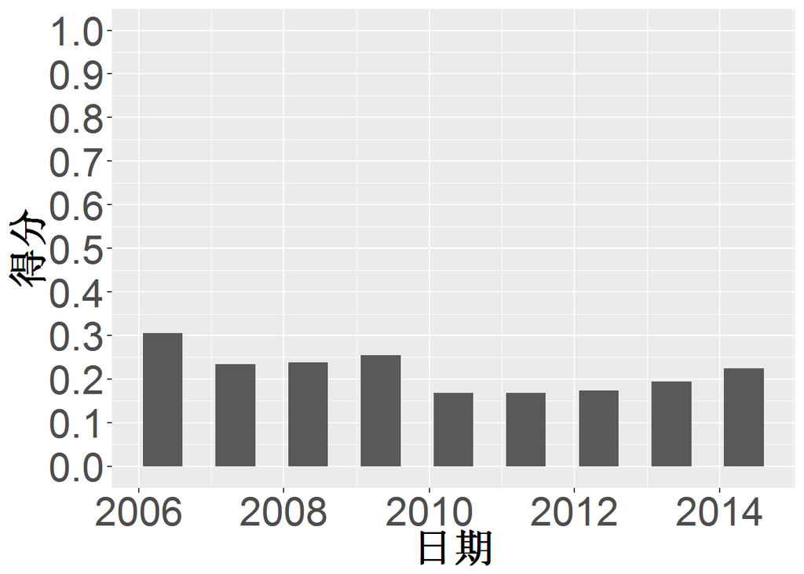

## 天津

```
##      人口    GD  二产  三产      高学      城市       pH        DO
## 2014 2.14 10.04 49.16 49.57 0.2178289 0.8226763 7.970192 10.226920
## 2013 2.28 12.54 50.60 48.10 0.2197531 0.8199728 7.942788  8.913846
## 2012 2.63 13.85 51.68 46.99 0.2165211 0.8152866 7.860965  9.112719
## 2011 2.50 16.40 52.40 46.20 0.1997927 0.8044280 8.253077  9.295481
## 2010 2.60 17.40 52.50 46.00 0.1816781 0.7959969 8.289706 10.169510
## 2009 2.60 16.55 53.00 45.30 0.1635634 0.7801303 8.012353  8.387549
## 2008 2.19 16.49 60.10 37.90 0.1484081 0.7721088 8.294510  8.732574
## 2007 2.05 15.50 57.30 40.50 0.1513743 0.7632287 8.390288  9.424904
## 2006 1.60 14.70 57.10 40.20 0.1459666 0.7572093 8.181731  9.822788
##            CO        NH 13类 污水  降水  建成 森林   人均      利用
## 2014 4.481731 0.5428846 12.3 91.0 442.2 34.93  9.9  76.08 2.1187335
## 2013 4.670192 0.9068269  5.8 90.0 462.3 34.93  9.9 101.49 1.6229508
## 2012 4.018421 1.0131580  3.8 88.2 850.3 34.88  9.9 237.99 0.7021858
## 2011 3.790385 0.6397115  7.0 86.8 593.1 34.53  9.9 115.96 1.4613385
## 2010 3.993137 0.4900980 16.0 85.3 470.4 32.06  9.9  72.80 2.4445652
## 2009 4.895098 1.0679410  6.0 80.1 604.3 30.33  9.9 126.79 1.5334646
## 2008 4.919802 0.6605882  9.0 72.4 640.7 34.50  8.1 159.76 1.2202186
## 2007 6.173077 0.4940385 10.9 61.4 512.4 37.50  8.1 103.29 2.0663130
## 2006 5.883654 0.7750962 15.0 58.9 468.1 37.00  8.1  95.47 2.2710188
```

评价标准如下：

```
##   人口   GD 二产 三产 高学 城市  pH  DO CO   NH 13类 污水 降水 建成 森林
## 1  6.3 8.25 25.0 65.0 0.20 0.84 6~9 7.5  2 0.15   80   80 1500   80   80
## 2  5.0 7.75 43.0 60.0 0.15 0.79 6~9 6.0  4 0.50   70   70 1000   60   60
## 3  4.1 7.25 52.0 51.4 0.12 0.69 6~9 5.0  6 1.00   60   60  700   50   50
## 4  3.5 7.00 52.7 46.0 0.10 0.50 6~9 3.0 10 1.50   50   40  500   40   40
## 5  2.5 6.75 55.0 35.4 0.06 0.47 6~9 2.0 15 2.00   40   20  100   20   20
##   人均 利用
## 1 2300  0.1
## 2 1700  0.3
## 3 1100  0.8
## 4  700  1.5
## 5  500  1.7
```

各指标所属的等级以及概率

```
##      2014 2013 2012 2011 2010 2009 2008 2007 2006
## 人口    5    5    5    5    5    5    5    5    5
## GD      1    1    1    1    1    1    1    1    1
## 二产    3    3    3    4    4    4    5    5    5
## 三产    3    4    4    4    4    4    5    5    5
## 高学    1    1    1    1    1    2    2    2    2
## 城市    1    1    1    2    2    2    2    2    2
## pH      1    1    1    1    1    1    1    1    1
## DO      1    1    1    1    1    1    1    1    1
## CO      2    2    2    2    2    2    2    3    3
## NH      2    3    3    2    2    3    2    2    3
## 13类    5    5    5    5    5    5    5    5    5
## 污水    1    1    1    1    1    1    2    3    3
## 降水    4    4    2    4    4    3    3    4    4
## 建成    4    4    4    4    4    4    4    4    4
## 森林    5    5    5    5    5    5    5    5    5
## 人均    5    5    5    5    5    5    5    5    5
## 利用    5    5    3    4    5    4    4    5    5
```

```
##           2014      2013      2012      2011      2010      2009      2008
## 人口 1.0000000 1.0000000 0.8700000 1.0000000 0.9000000 0.9000000 1.0000000
## GD   1.0000000 1.0000000 1.0000000 1.0000000 1.0000000 1.0000000 1.0000000
## 二产 0.6844444 0.8444444 0.9644444 0.5714286 0.7142857 0.8695652 1.0000000
## 三产 0.6611111 0.6111111 0.8166667 0.9629630 1.0000000 0.9339623 0.7641509
## 高学 1.0000000 1.0000000 1.0000000 0.9958538 0.6335614 0.7287310 0.9469382
## 城市 0.6535267 0.5994565 0.5057325 0.7114391 0.8800616 0.9013029 0.8210884
## pH   1.0000000 1.0000000 1.0000000 1.0000000 1.0000000 1.0000000 1.0000000
## DO   1.0000000 1.0000000 1.0000000 1.0000000 1.0000000 1.0000000 1.0000000
## CO   0.7591345 0.6649040 0.9907895 0.8951925 0.9965685 0.5524510 0.5400990
## NH   0.9142308 0.8136538 0.9736840 0.7205770 0.9717086 0.8641180 0.6788236
## 13类 1.0000000 1.0000000 1.0000000 1.0000000 1.0000000 1.0000000 1.0000000
## 污水 1.0000000 1.0000000 1.0000000 1.0000000 1.0000000 1.0000000 0.7600000
## 降水 0.8555000 0.9057500 0.5010000 0.5345000 0.9260000 0.5215000 0.7035000
## 建成 0.7465000 0.7465000 0.7440000 0.7265000 0.6030000 0.5165000 0.7250000
## 森林 1.0000000 1.0000000 1.0000000 1.0000000 1.0000000 1.0000000 1.0000000
## 人均 1.0000000 1.0000000 1.0000000 1.0000000 1.0000000 1.0000000 1.0000000
## 利用 1.0000000 0.6147541 0.8043716 0.9447693 1.0000000 0.8326772 0.6003123
##           2007      2006
## 人口 1.0000000 1.0000000
## GD   1.0000000 1.0000000
## 二产 1.0000000 1.0000000
## 三产 0.5188679 0.5471698
## 高学 0.9725141 0.8655526
## 城市 0.7322870 0.6720930
## pH   1.0000000 1.0000000
## DO   1.0000000 1.0000000
## CO   0.9567307 0.9418270
## NH   0.9829671 0.5501924
## 13类 1.0000000 1.0000000
## 污水 0.8600000 0.9450000
## 降水 0.9380000 0.9202500
## 建成 0.8750000 0.8500000
## 森林 1.0000000 1.0000000
## 人均 1.0000000 1.0000000
## 利用 1.0000000 1.0000000
```

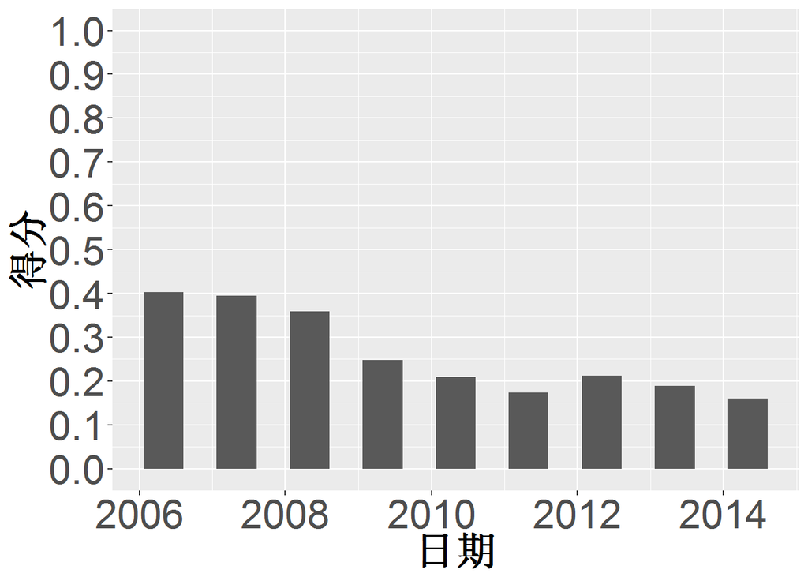

## 河北

```
##      人口    GD  二产  三产       高学      城市       pH       DO
## 2014 6.95  6.50 51.03 37.25 0.07297821 0.4932286 7.694200 8.636900
## 2013 6.17  8.20 52.20 35.50 0.07117008 0.4811128 7.892788 8.681250
## 2012 6.47  9.63 52.69 35.31 0.05315265 0.4680296 7.719126 8.929029
## 2011 6.50 11.30 53.50 34.60 0.04922326 0.4560144 7.951442 8.495481
## 2010 6.81 12.20 52.50 34.90 0.05058242 0.4449541 7.817030 8.509802
## 2009 6.50 10.03 52.00 35.20 0.05194158 0.4374467 7.859902 9.003725
## 2008 6.55 10.10 54.20 33.20 0.04474365 0.4189441 8.009697 7.388990
## 2007 6.55 12.80 52.80 34.00 0.03864506 0.4025637 7.942755 8.350408
## 2006 6.23 13.40 52.40 33.80 0.03674912 0.3876486 8.019808 8.015577
##            CO        NH     13类  污水  降水  建成 森林   人均      利用
## 2014 3.067000 0.4061000 41.03727 93.60 393.3 41.93 23.4 144.27 1.8163150
## 2013 3.267308 0.5643269 43.29236 93.20 559.3 41.20 23.4 240.57 1.0877402
## 2012 3.090291 0.6038835 43.22997 92.40 623.5 40.98 23.4 324.24 0.8293211
## 2011 3.146154 0.6848077 40.28855 92.30 515.4 42.07 23.4 217.75 1.2324531
## 2010 3.218000 0.7519802 42.07123 92.30 519.3 42.73 23.4 195.30 1.3941837
## 2009 3.260638 0.9191176 37.79280 85.00 534.5 40.02 23.4 201.32 1.3723434
## 2008 3.724194 2.5084850 29.68161 77.59 557.7 38.71 17.7 231.12 1.2113043
## 2007 3.065306 3.2039800 24.69011 66.12 461.5 36.50 17.7 173.09 1.6904583
## 2006 3.254808 3.5009620 27.27499 63.63 425.9 35.57 17.7 156.14 1.9005031
```

评价标准如下：

```
##   人口   GD 二产 三产 高学 城市  pH  DO CO   NH 13类 污水 降水 建成 森林
## 1  6.3 8.25 25.0 65.0 0.20 0.84 6~9 7.5  2 0.15   80   80 1500   80   80
## 2  5.0 7.75 43.0 60.0 0.15 0.79 6~9 6.0  4 0.50   70   70 1000   60   60
## 3  4.1 7.25 52.0 51.4 0.12 0.69 6~9 5.0  6 1.00   60   60  700   50   50
## 4  3.5 7.00 52.7 46.0 0.10 0.50 6~9 3.0 10 1.50   50   40  500   40   40
## 5  2.5 6.75 55.0 35.4 0.06 0.47 6~9 2.0 15 2.00   40   20  100   20   20
##   人均 利用
## 1 2300  0.1
## 2 1700  0.3
## 3 1100  0.8
## 4  700  1.5
## 5  500  1.7
```

各指标所属的等级以及概率

```
##      2014 2013 2012 2011 2010 2009 2008 2007 2006
## 人口    1    1    1    1    1    1    1    1    1
## GD      5    1    1    1    1    1    1    1    1
## 二产    3    3    4    4    4    3    5    4    4
## 三产    5    5    5    5    5    5    5    5    5
## 高学    5    5    5    5    5    5    5    5    5
## 城市    4    5    5    5    5    5    5    5    5
## pH      1    1    1    1    1    1    1    1    1
## DO      1    1    1    1    1    1    1    1    1
## CO      2    2    2    2    2    2    2    2    2
## NH      2    2    2    2    3    3    5    5    5
## 13类    5    5    5    5    5    5    5    5    5
## 污水    1    1    1    1    1    1    1    2    3
## 降水    4    4    3    4    4    4    4    4    4
## 建成    4    4    4    4    4    4    4    4    4
## 森林    5    5    5    5    5    5    5    5    5
## 人均    5    5    5    5    5    5    5    5    5
## 利用    5    3    3    4    4    4    4    5    5
```

```
##           2014      2013      2012      2011      2010      2009      2008
## 人口 1.0000000 0.9000000 1.0000000 1.0000000 1.0000000 1.0000000 1.0000000
## GD   1.0000000 0.9000000 1.0000000 1.0000000 1.0000000 1.0000000 1.0000000
## 二产 0.8922222 0.7142857 0.9857143 0.6521739 0.7142857 1.0000000 0.6521739
## 三产 0.8254717 0.9905660 1.0000000 1.0000000 1.0000000 1.0000000 1.0000000
## 高学 0.6755448 0.7207479 1.0000000 1.0000000 1.0000000 1.0000000 1.0000000
## 城市 0.7742867 0.6295741 1.0000000 1.0000000 1.0000000 1.0000000 1.0000000
## pH   1.0000000 1.0000000 1.0000000 1.0000000 1.0000000 1.0000000 1.0000000
## DO   1.0000000 1.0000000 1.0000000 1.0000000 1.0000000 1.0000000 0.9259933
## CO   0.5335000 0.6336540 0.5451455 0.5730770 0.6090000 0.6303190 0.8620970
## NH   0.7317143 0.8713462 0.7922330 0.6303846 0.5039604 0.8382352 1.0000000
## 13类 0.8962726 0.6707637 0.6770031 0.9711452 0.7928773 1.0000000 1.0000000
## 污水 1.0000000 1.0000000 1.0000000 1.0000000 1.0000000 1.0000000 0.7590000
## 降水 0.7332500 0.7035000 0.6175000 0.9230000 0.9035000 0.8275000 0.7115000
## 建成 0.8070000 0.8800000 0.9020000 0.7930000 0.7270000 0.9980000 0.9355000
## 森林 0.8300000 0.8300000 0.8300000 0.8300000 0.8300000 0.8300000 1.0000000
## 人均 1.0000000 1.0000000 1.0000000 1.0000000 1.0000000 1.0000000 1.0000000
## 利用 1.0000000 0.5889425 0.9581127 0.6177901 0.8488339 0.8176335 0.5875776
##           2007      2006
## 人口 1.0000000 0.9461538
## GD   1.0000000 1.0000000
## 二产 0.9565217 0.5714286
## 三产 1.0000000 1.0000000
## 高学 1.0000000 1.0000000
## 城市 1.0000000 1.0000000
## pH   1.0000000 1.0000000
## DO   1.0000000 1.0000000
## CO   0.5326530 0.6274040
## NH   1.0000000 1.0000000
## 13类 1.0000000 1.0000000
## 污水 0.6120000 0.6370000
## 降水 0.9037500 0.8147500
## 建成 0.8250000 0.7785000
## 森林 1.0000000 1.0000000
## 人均 1.0000000 1.0000000
## 利用 0.9522915 1.0000000
```

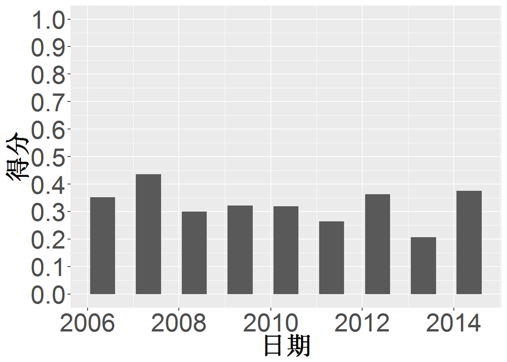

### 京津冀对比

选取2007年，进行对比，京津冀地区数据如下

```
##      人口   GD 二产 三产       高学      城市       pH       DO       CO
## 北京 3.40 14.5 26.8 72.1 0.28947368 0.8448687 7.897624 8.189802 2.485000
## 天津 2.05 15.5 57.3 40.5 0.15137429 0.7632287 8.390288 9.424904 6.173077
## 河北 6.55 12.8 52.8 34.0 0.03864506 0.4025637 7.942755 8.350408 3.065306
##             NH     13类  污水  降水  建成 森林   人均     利用
## 北京 0.1881188 50.70000 76.30 499.0 36.17 21.3 148.16 1.461991
## 天津 0.4940385 10.90000 61.40 512.4 37.50  8.1 103.29 2.066313
## 河北 3.2039800 24.69011 66.12 461.5 36.50 17.7 173.09 1.690458
```

评价标准如下：

```
##   人口   GD 二产 三产 高学 城市  pH  DO CO   NH 13类 污水 降水 建成 森林
## 1  6.3 8.25 25.0 65.0 0.20 0.84 6~9 7.5  2 0.15   80   80 1500   80   80
## 2  5.0 7.75 43.0 60.0 0.15 0.79 6~9 6.0  4 0.50   70   70 1000   60   60
## 3  4.1 7.25 52.0 51.4 0.12 0.69 6~9 5.0  6 1.00   60   60  700   50   50
## 4  3.5 7.00 52.7 46.0 0.10 0.50 6~9 3.0 10 1.50   50   40  500   40   40
## 5  2.5 6.75 55.0 35.4 0.06 0.47 6~9 2.0 15 2.00   40   20  100   20   20
##   人均 利用
## 1 2300  0.1
## 2 1700  0.3
## 3 1100  0.8
## 4  700  1.5
## 5  500  1.7
```

各指标所属的等级以及概率

```
##      北京 天津 河北
## 人口    4    5    1
## GD      1    1    1
## 二产    1    5    4
## 三产    1    5    5
## 高学    1    2    5
## 城市    1    2    5
## pH      1    1    1
## DO      1    1    1
## CO      1    3    2
## NH      1    2    5
## 13类    4    5    5
## 污水    1    3    2
## 降水    4    4    4
## 建成    4    4    4
## 森林    5    5    5
## 人均    5    5    5
## 利用    4    5    5
```

```
##           北京      天津      河北
## 人口 0.9000000 1.0000000 1.0000000
## GD   1.0000000 1.0000000 1.0000000
## 二产 0.9000000 1.0000000 0.9565217
## 三产 1.0000000 0.5188679 1.0000000
## 高学 1.0000000 0.9725141 1.0000000
## 城市 1.0000000 0.7322870 1.0000000
## pH   1.0000000 1.0000000 1.0000000
## DO   1.0000000 1.0000000 1.0000000
## CO   0.7575000 0.9567307 0.5326530
## NH   0.8910891 0.9829671 1.0000000
## 13类 0.9300000 1.0000000 1.0000000
## 污水 0.6300000 0.8600000 0.6120000
## 降水 0.9975000 0.9380000 0.9037500
## 建成 0.8085000 0.8750000 0.8250000
## 森林 0.9350000 1.0000000 1.0000000
## 人均 1.0000000 1.0000000 1.0000000
## 利用 0.9457011 1.0000000 0.9522915
```